# DL Assignment 2

## Oxford-IIIT Pet Dataset

**Student:** Alankar Sunil Uniyal  
**UID:** D2026PHIL0004

This notebook presents the final report for the multi-task CNN assignment on the Oxford-IIIT Pet Dataset. The implementation, training pipeline, evaluation utilities, and generated outputs are maintained in the accompanying Git repository.

**Code repository:** https://github.com/auniyal26/dl_assignment2

## Report Setup

This cell locates the project folder, loads the final experiment CSV files, and defines helpers for displaying the saved figures directly through Python.

```python
from pathlib import Path
import pandas as pd
import numpy as np
from IPython.display import display, Markdown, Image

def find_project_root(start=None):
    start = Path.cwd() if start is None else Path(start)
    for candidate in [start] + list(start.parents):
        if (candidate / "outputs").exists() and (candidate / "model.py").exists():
            return candidate
    raise FileNotFoundError(
        "Could not locate the project root containing model.py and outputs/."
    )

ROOT = find_project_root()
OUTPUT_DIR = ROOT / "outputs"
REPORT_DIR = OUTPUT_DIR / "report_30epoch"

comparison = pd.read_csv(OUTPUT_DIR / "comparison.csv")

history_paths = {
    "No Augmentation": OUTPUT_DIR / "no_augmentation_history.csv",
    "Geometric Augmentation": OUTPUT_DIR / "geometric_augmentation_history.csv",
    "Geometric + Appearance": OUTPUT_DIR / "geometric_plus_appearance_history.csv",
}
histories = {name: pd.read_csv(path) for name, path in history_paths.items()}

def show_report_image(filename, width=None):
    path = REPORT_DIR / filename
    if not path.exists():
        raise FileNotFoundError(f"Missing report figure: {path}")
    display(Image(filename=str(path), width=width))

def result_row(experiment):
    row = comparison.loc[comparison["Experiment"] == experiment]
    if len(row) != 1:
        raise ValueError(f"Could not uniquely identify experiment: {experiment}")
    return row.iloc[0]

def pct(x):
    return f"{100 * float(x):.2f}%"

print("Project root:", ROOT)
print("Report directory:", REPORT_DIR)
print("Comparison loaded:", (OUTPUT_DIR / "comparison.csv").exists())
print("All history files loaded:", all(p.exists() for p in history_paths.values()))
```

```
Project root: d:\Study Material\DL\Assignment 2
Report directory: d:\Study Material\DL\Assignment 2\outputs\report_30epoch
Comparison loaded: True
All history files loaded: True
```

# Question 1 — Multi-Task CNN for Classification and Semantic Segmentation

**Task:** Develop a single convolutional neural network that simultaneously:

1. predicts one of the **37 pet breeds**, and
2. predicts a **binary pet/background segmentation mask**.

The model must use a shared CNN encoder followed by separate classification and segmentation branches, must be trained jointly, and must not use a pretrained network or an existing segmentation architecture directly.

## 1. Dataset, Split, and Preprocessing

The Oxford-IIIT Pet dataset provides RGB images, 37 breed labels, and pixel-level trimaps. The official `trainval` split contains **3,680** samples and the official `test` split contains **3,669** samples.

A fixed random seed of **42** was used to split the official `trainval` set into:

| Split | Number of Samples | Source |
| --- | --- | --- |
| Training | 2,944 | 80% of official `trainval` |
| Validation | 736 | 20% of official `trainval` |
| Test | 3,669 | official `test` split |

The exact same train/validation/test indices were reused for all three augmentation experiments.

### Image Preprocessing

All images were resized to **128 × 128** pixels using bilinear interpolation. Each image was converted to a tensor and normalized channel-wise using

$$ \mu = (0.5, 0.5, 0.5), \qquad \sigma = (0.5, 0.5, 0.5) $$

which maps image tensors approximately from $[0,1]$ to $[-1,1]$.

### Segmentation-Mask Preprocessing

The Oxford-IIIT Pet trimap uses:

- `1`: pet
- `2`: background
- `3`: boundary

For binary semantic segmentation,

$$ M_{\text{binary}} = \mathbb{1} \left[ M_{\text{trimap}} \neq 2 \right] $$

so values `1` and `3` are foreground and value `2` is background.

Masks were resized using **nearest-neighbour interpolation** to preserve discrete labels.

### Annotation Anomaly Check

Seven samples in `trainval` and seven samples in the official test split contain all-background trimaps despite visibly containing pets. These masks were confirmed to exist in the raw dataset.

The anomalous test-mask indices are:

`[1093, 1690, 1858, 2292, 2837, 2856, 3473]`

They were retained in the official quantitative metrics and excluded only from deliberate qualitative failure selection.

### Answer

The final split is **2,944 training / 736 validation / 3,669 test images**. Images are resized to $128 \times 128$, converted to tensors, and normalized to approximately $[-1,1]$. Trimaps are converted to binary masks with values `1` and `3` as foreground and value `2` as background.

## 2. Architecture

A custom multi-task encoder-decoder network was implemented from scratch. The model contains four shared convolutional encoder blocks, a classification branch, and a four-stage segmentation decoder. Skip connections pass encoder features to corresponding decoder stages.

Each `ConvBlock` contains two $3 \times 3$ convolutions followed by ReLU activations. All convolutions use padding 1. A $2 \times 2$ max-pooling operation reduces spatial resolution between encoder blocks.

### Complete Architecture

| Component | Input | Operation | Output | Activation |
| --- | --- | --- | --- | --- |
| Encoder Block 1 | $3 \times 128 \times 128$ | 2 × Conv $3 \times 3$, 32 channels | $32 \times 128 \times 128$ | ReLU |
| MaxPool | $32 \times 128 \times 128$ | $2 \times 2$ | $32 \times 64 \times 64$ | — |
| Encoder Block 2 | $32 \times 64 \times 64$ | 2 × Conv $3 \times 3$, 64 channels | $64 \times 64 \times 64$ | ReLU |
| MaxPool | $64 \times 64 \times 64$ | $2 \times 2$ | $64 \times 32 \times 32$ | — |
| Encoder Block 3 | $64 \times 32 \times 32$ | 2 × Conv $3 \times 3$, 128 channels | $128 \times 32 \times 32$ | ReLU |
| MaxPool | $128 \times 32 \times 32$ | $2 \times 2$ | $128 \times 16 \times 16$ | — |
| Encoder Block 4 | $128 \times 16 \times 16$ | 2 × Conv $3 \times 3$, 256 channels | $256 \times 16 \times 16$ | ReLU |
| Bottleneck Pool | $256 \times 16 \times 16$ | $2 \times 2$ | $256 \times 8 \times 8$ | — |
| Classification GAP | $256 \times 8 \times 8$ | Adaptive global average pooling | $256 \times 1 \times 1$ | — |
| Classification FC | 256 | Linear 256 → 128 | 128 | ReLU + Dropout(0.30) |
| Classification Output | 128 | Linear 128 → 37 | 37 logits | — |
| Decoder Up 4 | $256 \times 8 \times 8$ | Transposed Conv $2 \times 2$, 128 | $128 \times 16 \times 16$ | — |
| Skip + Decoder Block 4 | $(128 + 256)$ channels | 2 × Conv $3 \times 3$, 128 | $128 \times 16 \times 16$ | ReLU |
| Decoder Up 3 | $128 \times 16 \times 16$ | Transposed Conv $2 \times 2$, 64 | $64 \times 32 \times 32$ | — |
| Skip + Decoder Block 3 | $(64 + 128)$ channels | 2 × Conv $3 \times 3$, 64 | $64 \times 32 \times 32$ | ReLU |
| Decoder Up 2 | $64 \times 32 \times 32$ | Transposed Conv $2 \times 2$, 32 | $32 \times 64 \times 64$ | — |
| Skip + Decoder Block 2 | $(32 + 64)$ channels | 2 × Conv $3 \times 3$, 32 | $32 \times 64 \times 64$ | ReLU |
| Decoder Up 1 | $32 \times 64 \times 64$ | Transposed Conv $2 \times 2$, 32 | $32 \times 128 \times 128$ | — |
| Skip + Decoder Block 1 | $(32 + 32)$ channels | 2 × Conv $3 \times 3$, 32 | $32 \times 128 \times 128$ | ReLU |
| Segmentation Output | $32 \times 128 \times 128$ | Conv $1 \times 1$, 1 channel | $1 \times 128 \times 128$ logits | — |

The classification branch uses global average pooling to produce a compact feature vector. The segmentation branch uses transposed convolutions for learned upsampling and skip connections to restore spatial detail.

```python
from model import MultiTaskPetCNN

model = MultiTaskPetCNN()
trainable_parameters = sum(
    p.numel() for p in model.parameters() if p.requires_grad
)

display(Markdown(f"""
### Trainable Parameters

The implemented model contains

$$
\\boxed{{{trainable_parameters:,} \\text{{ trainable parameters}}}}
$$

### Answer

The final model uses four encoder blocks and four decoder blocks, satisfying the assignment requirements. It is trained from scratch, uses a shared encoder, produces 37 classification logits, and reconstructs a full-resolution binary segmentation mask.
"""))
```

Trainable Parameters

The implemented model contains

$$ \boxed{2,188,646 \text{ trainable parameters}} $$

Answer

The final model uses four encoder blocks and four decoder blocks, satisfying the assignment requirements. It is trained from scratch, uses a shared encoder, produces 37 classification logits, and reconstructs a full-resolution binary segmentation mask.

## 3. Loss Functions

### Classification Loss

Breed classification uses multi-class cross-entropy:

$$ L_{\text{cls}} = -\frac{1}{N} \sum_{i=1}^{N} \log p_{i,y_i} $$

### Segmentation Loss

The segmentation objective combines binary cross-entropy with Dice loss:

$$ L_{\text{seg}} = 0.5L_{\text{BCE}} + 0.5L_{\text{Dice}} $$

For soft probabilities $p_i = \sigma(z_i)$,

$$ D = \frac{ 2\sum_i p_i y_i + \epsilon }{ \sum_i p_i + \sum_i y_i + \epsilon } $$

and

$$ L_{\text{Dice}} = 1 - D $$

### Joint Multi-Task Loss

$$ L_{\text{total}} = 1.0L_{\text{cls}} + 1.0L_{\text{seg}} $$

### Answer

Classification uses cross-entropy. Segmentation uses an equal combination of BCE-with-logits and Dice loss. The two task losses are combined with equal task-level weights of 1.0.

## 4. Training Configuration

```python
import config as cfg

settings = pd.DataFrame([
    ("Optimizer", "Adam"),
    ("Initial learning rate", f"{cfg.LR:.1e}"),
    ("Batch size", cfg.BATCH_SIZE),
    ("Maximum epochs", cfg.EPOCHS),
    ("Random seed", cfg.SEED),
    ("Image resolution", f"{cfg.IMG_SIZE} × {cfg.IMG_SIZE}"),
    ("Classification-loss weight", cfg.CLS_WEIGHT),
    ("Segmentation-loss weight", cfg.SEG_WEIGHT),
    ("LR scheduler", "ReduceLROnPlateau"),
    ("Scheduler monitor", "joint validation loss"),
    ("LR reduction factor", cfg.LR_FACTOR),
    ("Scheduler patience", cfg.LR_PATIENCE),
    ("Relative threshold", f"{cfg.LR_THRESHOLD:.1e}"),
    ("Minimum learning rate", f"{cfg.LR_MIN:.1e}"),
    ("Checkpoint selection", "lowest joint validation loss"),
], columns=["Setting", "Value"])

display(settings)
```

|  | Setting | Value |
| --- | --- | --- |
| 0 | Optimizer | Adam |
| 1 | Initial learning rate | 1.0e-03 |
| 2 | Batch size | 32 |
| 3 | Maximum epochs | 30 |
| 4 | Random seed | 42 |
| 5 | Image resolution | 128 × 128 |
| 6 | Classification-loss weight | 1.0 |
| 7 | Segmentation-loss weight | 1.0 |
| 8 | LR scheduler | ReduceLROnPlateau |
| 9 | Scheduler monitor | joint validation loss |
| 10 | LR reduction factor | 0.5 |
| 11 | Scheduler patience | 2 |
| 12 | Relative threshold | 1.0e-03 |
| 13 | Minimum learning rate | 1.0e-05 |
| 14 | Checkpoint selection | lowest joint validation loss |

The scheduler policy was identical across all three experiments. Because `ReduceLROnPlateau` is adaptive, the realized learning-rate trajectory can differ between experiments.

The final model checkpoint for each experiment is selected using the **lowest joint validation loss**.

### Training and Validation Loss

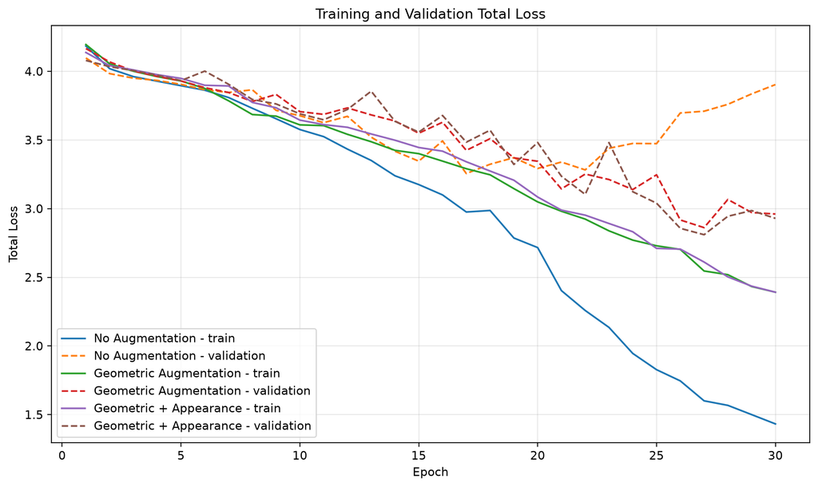

```python
show_report_image("loss_curves_30epoch.png")
```

### Learning-Rate Schedule

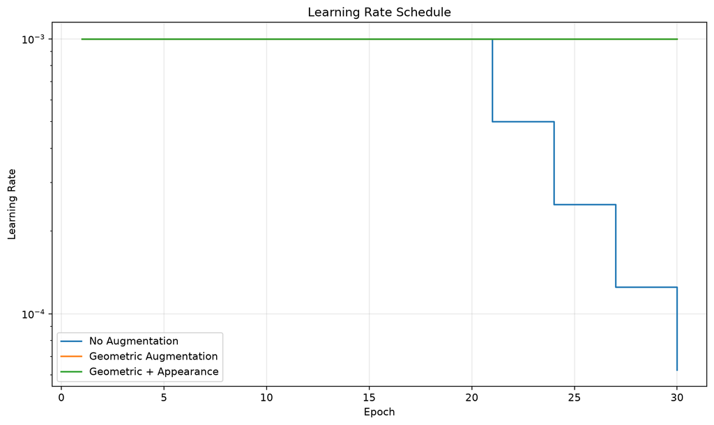

```python
show_report_image("learning_rate_schedule_30epoch.png")
```

```python
best_rows = []

for name, h in histories.items():
    idx = h["val_loss"].idxmin()
    best_rows.append({
        "Experiment": name,
        "Best Validation-Loss Epoch": int(h.loc[idx, "epoch"]),
        "Minimum Validation Loss": h.loc[idx, "val_loss"],
    })

display(pd.DataFrame(best_rows).round({"Minimum Validation Loss": 4}))

display(Markdown("""
### Answer

All three experiments use the same architecture, split, optimizer, initial learning rate, batch size, maximum epoch count, loss formulation, scheduler configuration, and checkpoint-selection rule. The augmentation strategy is therefore the main controlled experimental factor.
"""))
```

|  | Experiment | Best Validation-Loss Epoch | Minimum Validation Loss |
| --- | --- | --- | --- |
| 0 | No Augmentation | 17 | 3.2561 |
| 1 | Geometric Augmentation | 27 | 2.8619 |
| 2 | Geometric + Appearance | 27 | 2.8103 |

Answer

All three experiments use the same architecture, split, optimizer, initial learning rate, batch size, maximum epoch count, loss formulation, scheduler configuration, and checkpoint-selection rule. The augmentation strategy is therefore the main controlled experimental factor.

## 5. Baseline Classification Performance

```python
baseline = result_row("No Augmentation")
chance = 1 / 37

display(Markdown(f"""
The baseline test classification accuracy is

$$
\\boxed{{{100*baseline["Classification Accuracy"]:.2f}\\%}}
$$

For context, random-chance accuracy in a 37-class problem is approximately **{100*chance:.2f}%**.

### Answer

The baseline model achieves **{100*baseline["Classification Accuracy"]:.2f}% test classification accuracy**.
"""))
```

The baseline test classification accuracy is

$$ \boxed{14.01\%} $$

For context, random-chance accuracy in a 37-class problem is approximately **2.70%**.

Answer

The baseline model achieves **14.01% test classification accuracy**.

### Baseline Confusion Matrix

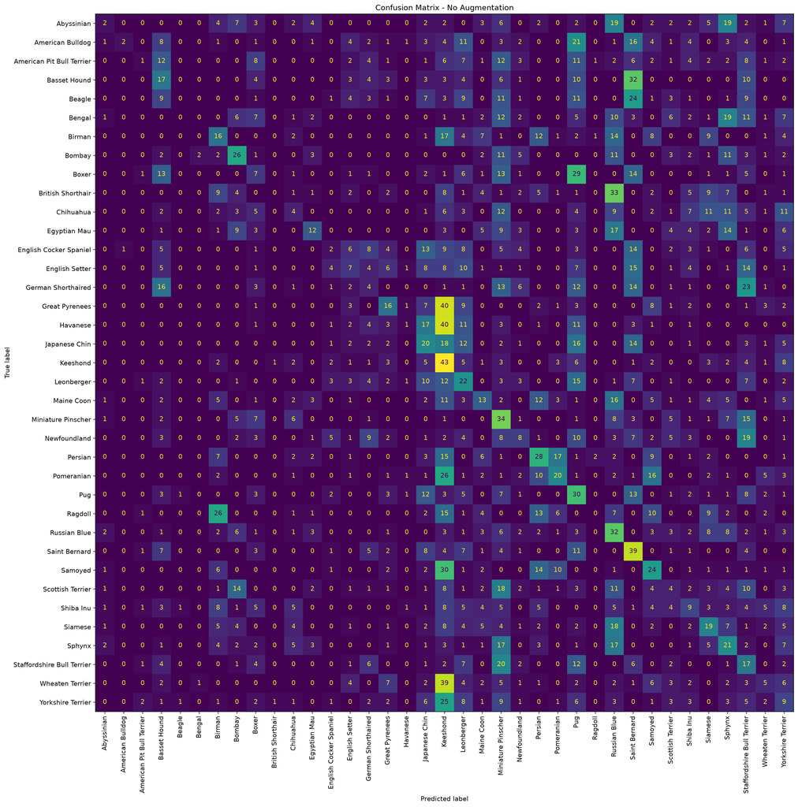

```python
show_report_image("no_augmentation_confusion_matrix_30epoch.png")
```

## 6. Baseline Segmentation Performance

For a predicted binary mask $P$ and ground-truth mask $G$,

$$ \text{IoU} = \frac{|P \cap G|}{|P \cup G|} $$

and

$$ \text{Dice} = \frac{2|P \cap G|}{|P| + |G|} $$

```python
baseline_table = pd.DataFrame({
    "Metric": ["Mean IoU", "Mean Dice"],
    "Full Official Test Set": [
        baseline["Mean IoU"],
        baseline["Mean Dice"],
    ],
    "Valid-Mask-Only Sensitivity Check": [
        baseline["Valid-mask Mean IoU"],
        baseline["Valid-mask Mean Dice"],
    ],
})

display(baseline_table.round(6))

display(Markdown(f"""
### Answer

The baseline segmentation branch achieves **mean IoU = {baseline["Mean IoU"]:.4f}**
and **mean Dice = {baseline["Mean Dice"]:.4f}** on the full official test split.
"""))
```

|  | Metric | Full Official Test Set | Valid-Mask-Only Sensitivity Check |
| --- | --- | --- | --- |
| 0 | Mean IoU | 0.760719 | 0.762173 |
| 1 | Mean Dice | 0.853994 | 0.855626 |

Answer

The baseline segmentation branch achieves **mean IoU = 0.7607** and **mean Dice = 0.8540** on the full official test split.

## 7. Baseline Qualitative Segmentation Analysis

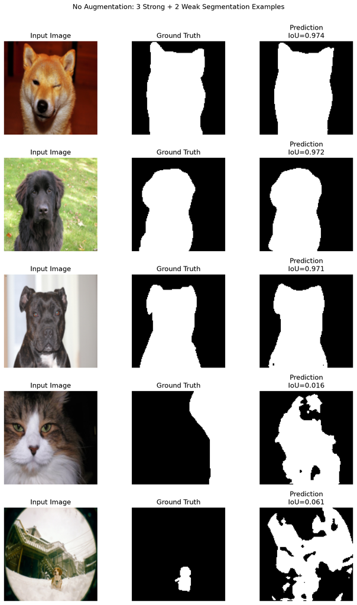

```python
show_report_image("no_augmentation_segmentation_examples_30epoch.png")
```

Successful cases generally contain a clearly visible pet occupying a substantial portion of the frame with a distinct object boundary.

Difficult cases tend to involve:

- a small or distant pet,
- unusual framing or partial visibility,
- cluttered background structure,
- low contrast between animal and background,
- fine boundary details lost during encoder downsampling.

### Answer

The network is strongest when the pet is large, clearly visible, and spatially separated from the background. Failures are concentrated in scenes with small foreground regions, clutter, unusual framing, or ambiguous boundaries.

# Question 2 — Effect of Data Augmentation

The same architecture, split, optimizer, scheduler policy, batch size, maximum epoch count, loss formulation, and checkpoint-selection rule were used for all three experiments. The augmentation strategy was the controlled difference.

## 8. Augmentation Strategies

### Experiment A — No Augmentation

Training images receive only deterministic resizing, tensor conversion, and normalization.

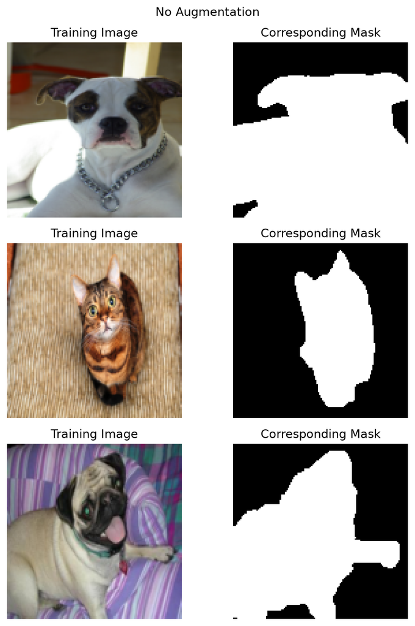

```python
show_report_image("baseline_augmentation_examples.png")
```

### Experiment B — Geometric Augmentation

Training-time transforms:

- random resized crop with scale range 0.80–1.00,
- crop aspect-ratio range 0.90–1.10,
- random horizontal flip with probability 0.5,
- random rotation between $-15^\circ$ and $+15^\circ$.

Each geometric transform is applied consistently to both image and mask. Images use bilinear interpolation; masks use nearest-neighbour interpolation.

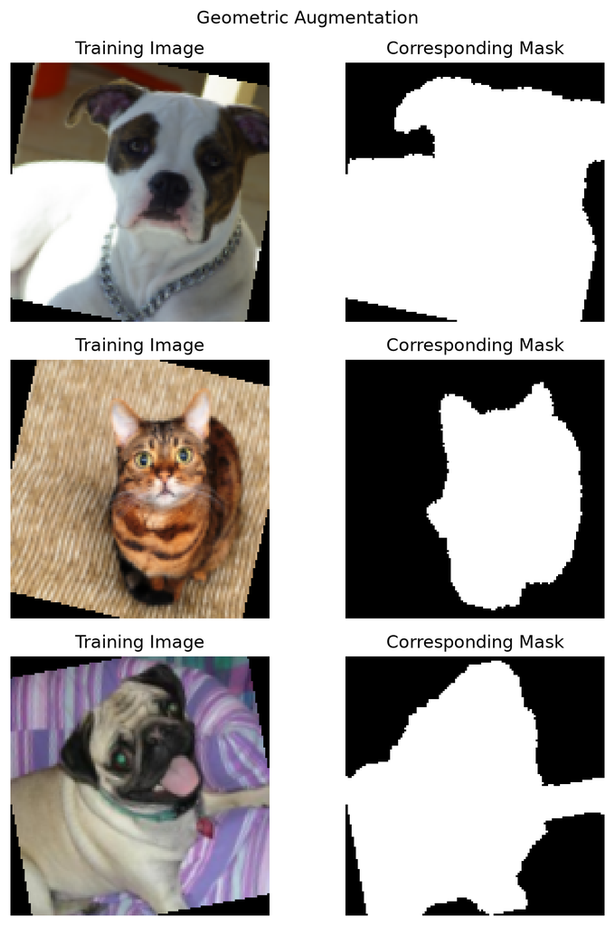

```python
show_report_image("geometric_augmentation_examples.png")
```

### Experiment C — Geometric + Appearance Augmentation

Experiment C uses all geometric transforms from Experiment B and adds image-only color jitter:

- brightness = 0.25,
- contrast = 0.25,
- saturation = 0.25.

Appearance transforms are applied only to the image, never to the segmentation mask.

Validation and test preprocessing remain deterministic for all experiments.

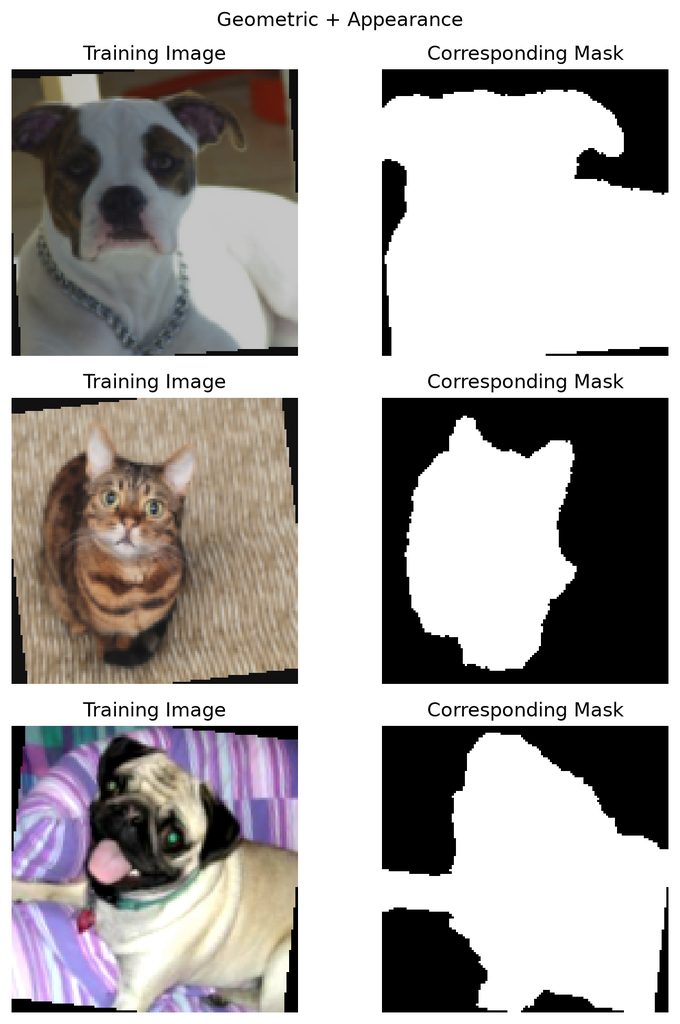

```python
show_report_image("geometric_plus_appearance_augmentation_examples.png")
```

## 9. Final Quantitative Comparison

```python
display_table = comparison.copy()
display_table["Classification Accuracy"] = display_table["Classification Accuracy"].map(
    lambda x: f"{100*x:.2f}%"
)

for col in ["Mean IoU", "Mean Dice", "Valid-mask Mean IoU", "Valid-mask Mean Dice"]:
    display_table[col] = display_table[col].map(lambda x: f"{x:.4f}")

display(display_table)

best_cls = comparison.loc[comparison["Classification Accuracy"].idxmax()]
best_iou = comparison.loc[comparison["Mean IoU"].idxmax()]
best_dice = comparison.loc[comparison["Mean Dice"].idxmax()]

baseline_row = result_row("No Augmentation")
geo_row = result_row("Geometric Augmentation")
app_row = result_row("Geometric + Appearance")

geo_gain = 100 * (
    geo_row["Classification Accuracy"] - baseline_row["Classification Accuracy"]
)
app_gain = 100 * (
    app_row["Classification Accuracy"] - geo_row["Classification Accuracy"]
)

display(Markdown(f"""
Geometric augmentation improves classification by **{geo_gain:.2f} percentage points**
relative to the baseline. Appearance augmentation adds a further **{app_gain:.2f}
percentage-point** improvement over geometric augmentation.

**Best classification:** {best_cls["Experiment"]} — {100*best_cls["Classification Accuracy"]:.2f}%
**Best mean IoU:** {best_iou["Experiment"]} — {best_iou["Mean IoU"]:.4f}
**Best mean Dice:** {best_dice["Experiment"]} — {best_dice["Mean Dice"]:.4f}
"""))
```

|  | Experiment | Classification Accuracy | Mean IoU | Mean Dice | Valid-mask Mean IoU | Valid-mask Mean Dice |
| --- | --- | --- | --- | --- | --- | --- |
| 0 | No Augmentation | 14.01% | 0.7607 | 0.8540 | 0.7622 | 0.8556 |
| 1 | Geometric Augmentation | 24.50% | 0.7623 | 0.8547 | 0.7638 | 0.8563 |
| 2 | Geometric + Appearance | 27.45% | 0.7520 | 0.8474 | 0.7534 | 0.8491 |

Geometric augmentation improves classification by **10.49 percentage points** relative to the baseline. Appearance augmentation adds a further **2.94 percentage-point** improvement over geometric augmentation.

**Best classification:** Geometric + Appearance — 27.45%  
**Best mean IoU:** Geometric Augmentation — 0.7623  
**Best mean Dice:** Geometric Augmentation — 0.8547

## 10. Training and Validation Performance

### Classification Accuracy

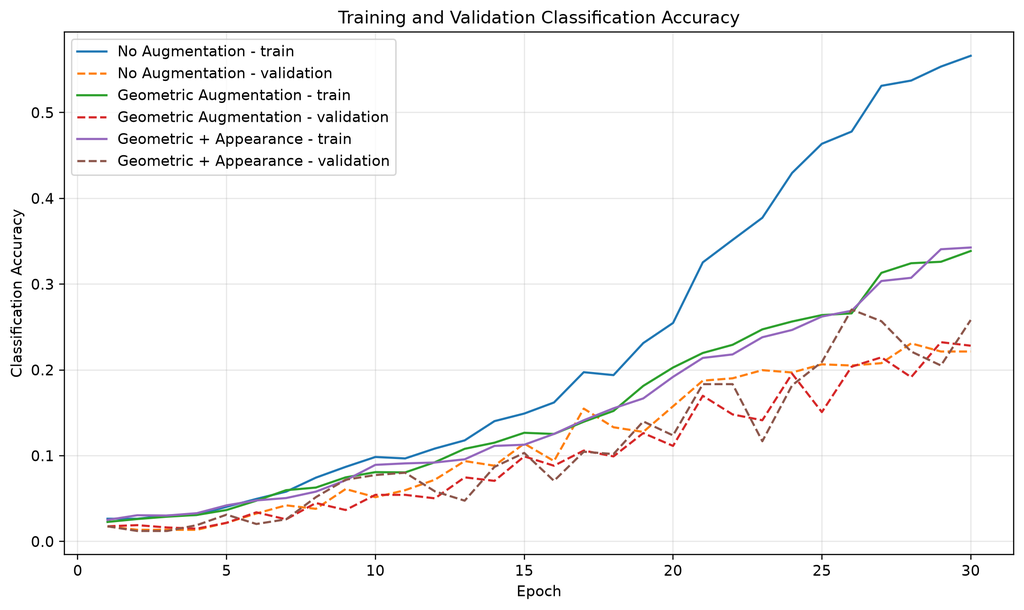

```python
show_report_image("accuracy_curves_30epoch.png")
```

### Mean IoU

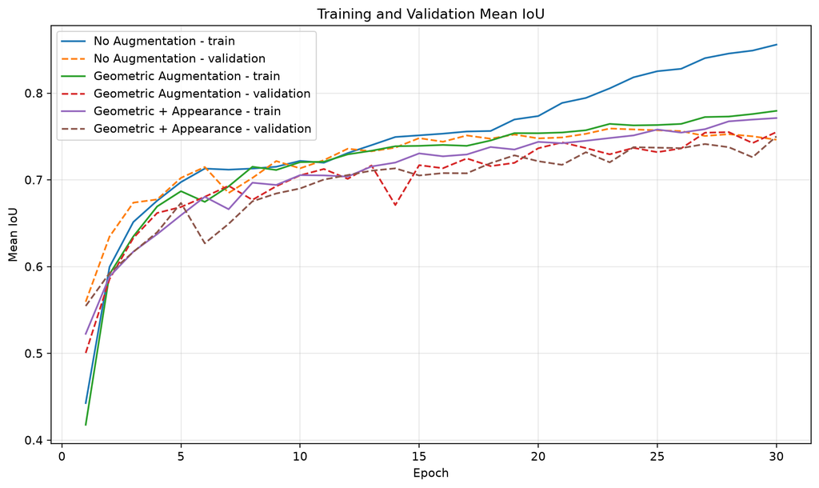

```python
show_report_image("iou_curves_30epoch.png")
```

### Mean Dice

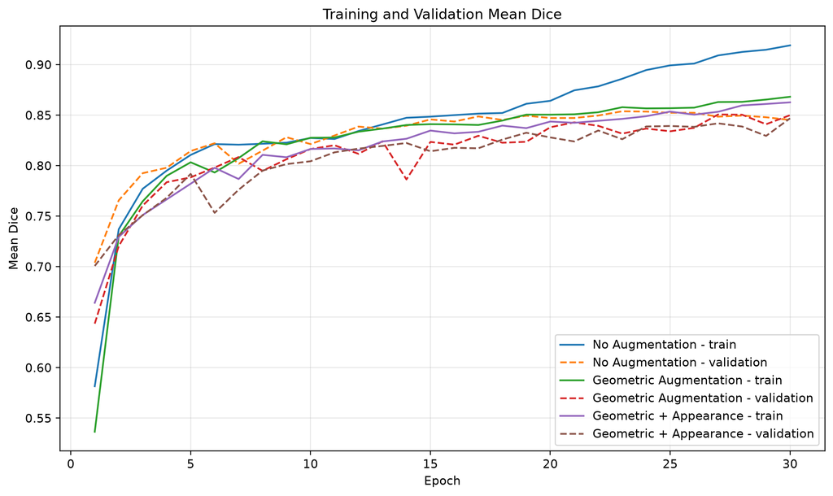

```python
show_report_image("dice_curves_30epoch.png")
```

```python
gap_rows = []

for name, h in histories.items():
    last = h.iloc[-1]
    gap_rows.append({
        "Experiment": name,
        "Train Accuracy": last["train_accuracy"],
        "Validation Accuracy": last["val_accuracy"],
        "Accuracy Gap": last["train_accuracy"] - last["val_accuracy"],
        "Train IoU": last["train_iou"],
        "Validation IoU": last["val_iou"],
        "IoU Gap": last["train_iou"] - last["val_iou"],
        "Validation - Training Loss": last["val_loss"] - last["train_loss"],
    })

gap_table = pd.DataFrame(gap_rows)
display(gap_table.round(4))

baseline_gap = gap_table.loc[gap_table["Experiment"] == "No Augmentation"].iloc[0]
geo_gap = gap_table.loc[gap_table["Experiment"] == "Geometric Augmentation"].iloc[0]
app_gap = gap_table.loc[gap_table["Experiment"] == "Geometric + Appearance"].iloc[0]
```

|  | Experiment | Train Accuracy | Validation Accuracy | Accuracy Gap | Train IoU | Validation IoU | IoU Gap | Validation - Training Loss |
| --- | --- | --- | --- | --- | --- | --- | --- | --- |
| 0 | No Augmentation | 0.5662 | 0.2215 | 0.3448 | 0.8560 | 0.7464 | 0.1096 | 2.4709 |
| 1 | Geometric Augmentation | 0.3387 | 0.2283 | 0.1104 | 0.7796 | 0.7552 | 0.0245 | 0.5693 |
| 2 | Geometric + Appearance | 0.3427 | 0.2582 | 0.0846 | 0.7713 | 0.7502 | 0.0212 | 0.5377 |

## 11. Confusion Matrices

### No Augmentation

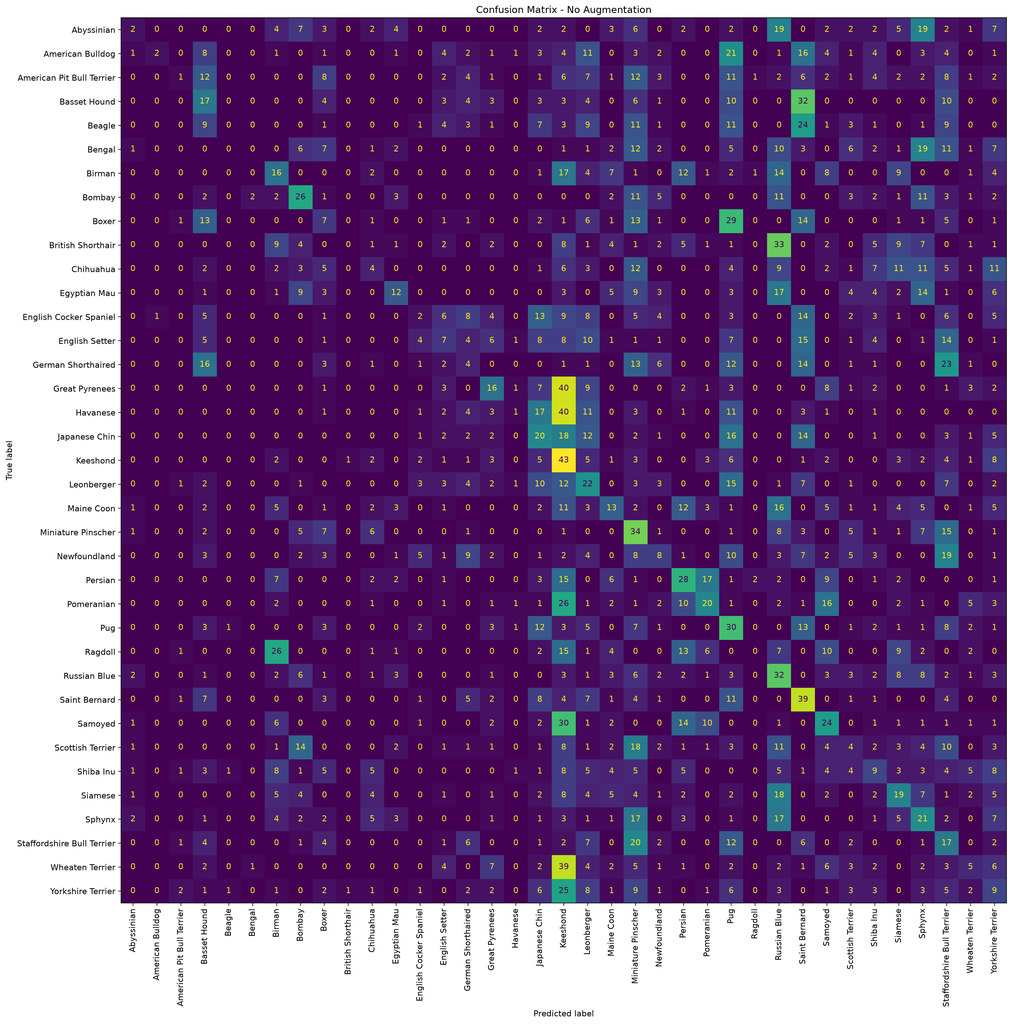

```python
show_report_image("no_augmentation_confusion_matrix_30epoch.png")
```

### Geometric Augmentation

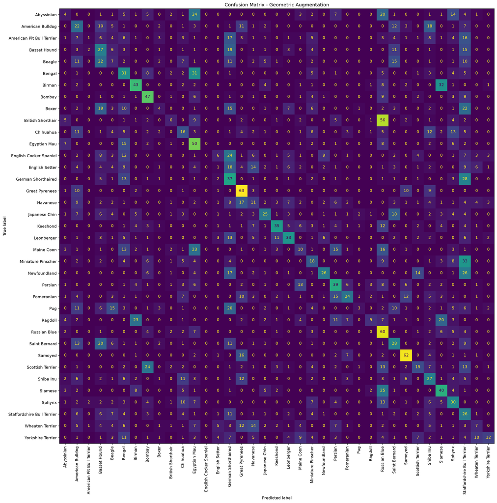

```python
show_report_image("geometric_augmentation_confusion_matrix_30epoch.png")
```

### Geometric + Appearance Augmentation

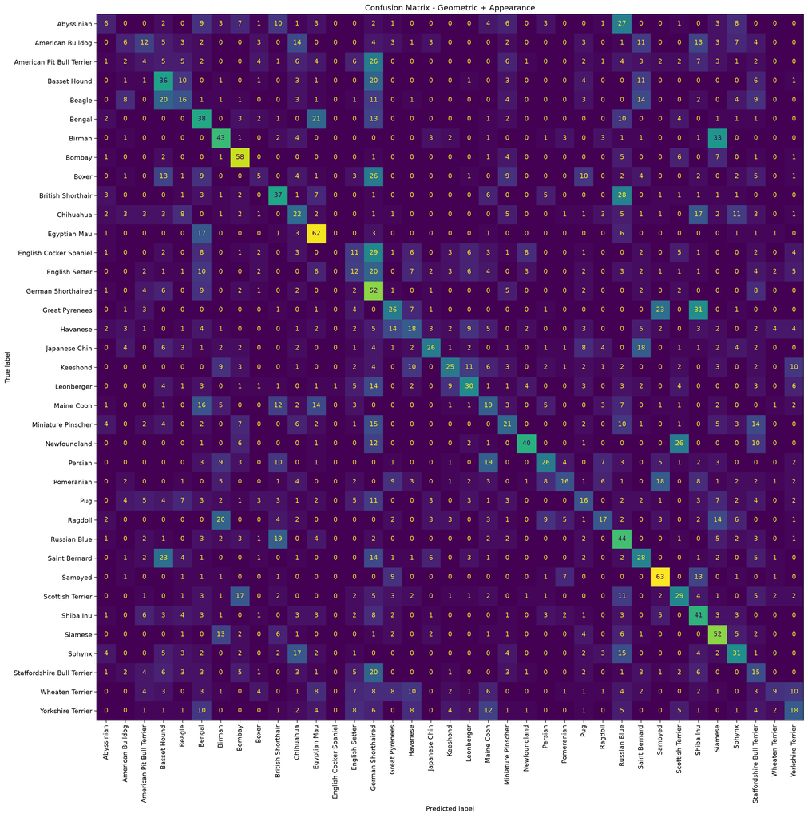

```python
show_report_image("geometric_plus_appearance_confusion_matrix_30epoch.png")
```

## 12. Segmentation Examples for Augmented Models

### Geometric Augmentation

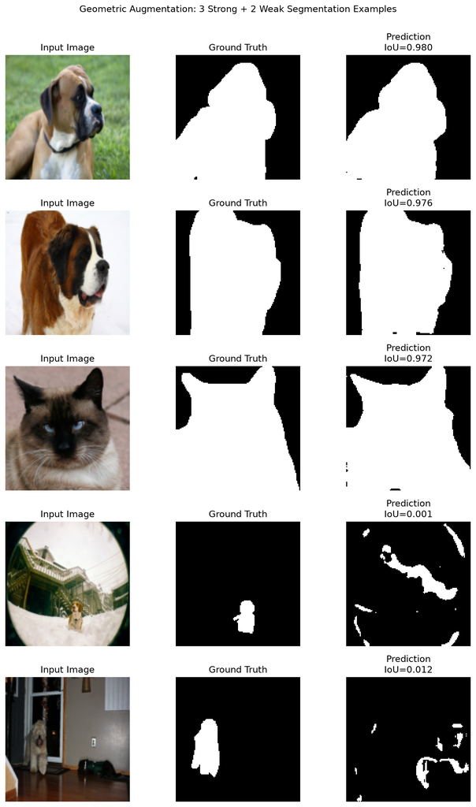

```python
show_report_image("geometric_augmentation_segmentation_examples_30epoch.png")
```

### Geometric + Appearance Augmentation

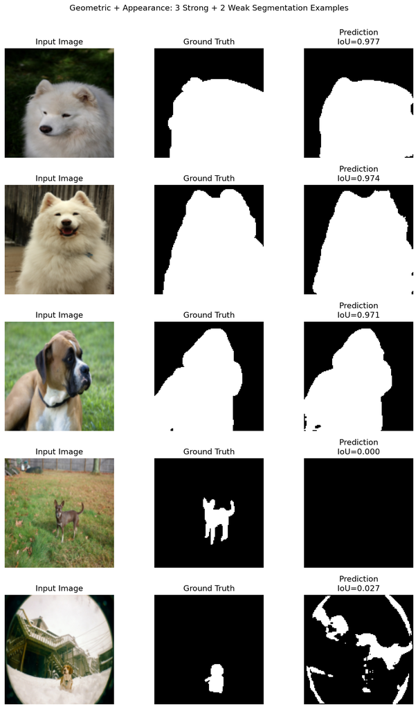

```python
show_report_image("geometric_plus_appearance_segmentation_examples_30epoch.png")
```

# 13. Required Discussion

```python
best_cls_name = str(best_cls.loc["Experiment"])
best_cls_acc = float(best_cls.loc["Classification Accuracy"])

best_seg_name = str(best_iou.loc["Experiment"])
best_seg_iou = float(best_iou.loc["Mean IoU"])
best_seg_dice = float(
    comparison.loc[
        comparison["Experiment"] == best_seg_name,
        "Mean Dice"
    ].iloc[0]
)

baseline_acc = float(baseline_row.loc["Classification Accuracy"])
geo_acc = float(geo_row.loc["Classification Accuracy"])
app_acc = float(app_row.loc["Classification Accuracy"])

baseline_iou = float(baseline_row.loc["Mean IoU"])
geo_iou = float(geo_row.loc["Mean IoU"])
app_iou = float(app_row.loc["Mean IoU"])

baseline_dice = float(baseline_row.loc["Mean Dice"])
geo_dice = float(geo_row.loc["Mean Dice"])
app_dice = float(app_row.loc["Mean Dice"])

baseline_acc_gap = float(baseline_gap.loc["Accuracy Gap"])
geo_acc_gap = float(geo_gap.loc["Accuracy Gap"])
app_acc_gap = float(app_gap.loc["Accuracy Gap"])

baseline_iou_gap = float(baseline_gap.loc["IoU Gap"])
geo_iou_gap = float(geo_gap.loc["IoU Gap"])
app_iou_gap = float(app_gap.loc["IoU Gap"])
```

```python
display(Markdown(f"""
## 13.1 Which augmentation strategy gives the best classification performance?

**Geometric + Appearance Augmentation gives the best classification performance.**

Its test accuracy is

$$
\\boxed{{{100*app_acc:.2f}\\%}}
$$

compared with **{100*geo_acc:.2f}%** for Geometric Augmentation and
**{100*baseline_acc:.2f}%** for No Augmentation.

The addition of appearance transformations therefore improves classification beyond
geometric augmentation alone. The result suggests that breed recognition benefits from
invariance to changes in brightness, contrast, and color as well as geometry.

### Answer

**Geometric + Appearance Augmentation is best for classification, with
{100*app_acc:.2f}% test accuracy.**

---

## 13.2 Which augmentation strategy gives the best segmentation performance?

**Geometric Augmentation gives the best segmentation performance.**

It achieves

$$
\\boxed{{\\text{{Mean IoU}} = {geo_iou:.4f}}}
$$

and

$$
\\boxed{{\\text{{Mean Dice}} = {geo_dice:.4f}}}
$$

compared with IoU/Dice values of **{baseline_iou:.4f}/{baseline_dice:.4f}**
for No Augmentation and **{app_iou:.4f}/{app_dice:.4f}** for
Geometric + Appearance Augmentation.

### Answer

**Geometric Augmentation is best for segmentation, with mean IoU
{geo_iou:.4f} and mean Dice {geo_dice:.4f}.**

---

## 13.3 Does augmentation affect classification and segmentation in the same way?

No. The effect is clearly task-dependent.

Classification accuracy improves substantially:

- No Augmentation: **{100*baseline_acc:.2f}%**
- Geometric Augmentation: **{100*geo_acc:.2f}%**
- Geometric + Appearance: **{100*app_acc:.2f}%**

Segmentation behaves differently:

- No Augmentation IoU: **{baseline_iou:.4f}**
- Geometric Augmentation IoU: **{geo_iou:.4f}**
- Geometric + Appearance IoU: **{app_iou:.4f}**

Geometric augmentation slightly improves segmentation while strongly improving
classification. Adding appearance augmentation improves classification further but
reduces segmentation performance.

A plausible explanation is that classification benefits from invariance to appearance,
whereas segmentation depends more directly on spatial and local contrast cues required
to separate foreground from background.

### Answer

**No.** Augmentation benefits classification much more strongly than segmentation.
Appearance augmentation improves classification but slightly harms segmentation.

---

## 13.4 Does augmentation reduce the difference between training and validation performance?

Yes.

At the final epoch, the classification train-validation accuracy gaps are:

- No Augmentation: **{100*baseline_acc_gap:.2f} percentage points**
- Geometric Augmentation: **{100*geo_acc_gap:.2f} percentage points**
- Geometric + Appearance: **{100*app_acc_gap:.2f} percentage points**

The corresponding IoU gaps are:

- No Augmentation: **{baseline_iou_gap:.4f}**
- Geometric Augmentation: **{geo_iou_gap:.4f}**
- Geometric + Appearance: **{app_iou_gap:.4f}**

The non-augmented model therefore shows a much larger train-validation separation,
while both augmentation strategies keep training and validation performance closer.

### Answer

**Yes.** Both augmentation strategies reduce the train-validation gap and therefore
act as effective regularizers.

---

## 13.5 Are there any augmentations that appear to hurt performance?

Yes, but the effect is specific to the segmentation task.

Adding appearance augmentation improves classification from
**{100*geo_acc:.2f}%** to **{100*app_acc:.2f}%**, but segmentation decreases from

- IoU: **{geo_iou:.4f} → {app_iou:.4f}**
- Dice: **{geo_dice:.4f} → {app_dice:.4f}**

Therefore, appearance augmentation appears mildly harmful to segmentation under the
current multi-task architecture.

A plausible reason is that brightness, contrast, and saturation perturbations encourage
the shared encoder to become more invariant to appearance. This is useful for breed
classification but can weaken local intensity, texture, or contrast cues that contribute
to precise foreground-background separation.

### Answer

**Appearance augmentation mildly hurts segmentation while improving classification.
Geometric augmentation provides the best overall balance between the two tasks.**
"""))
```

13.1 Which augmentation strategy gives the best classification performance?

**Geometric + Appearance Augmentation gives the best classification performance.**

Its test accuracy is

$$ \boxed{27.45\%} $$

compared with **24.50%** for Geometric Augmentation and **14.01%** for No Augmentation.

The addition of appearance transformations therefore improves classification beyond geometric augmentation alone. The result suggests that breed recognition benefits from invariance to changes in brightness, contrast, and color as well as geometry.

Answer

**Geometric + Appearance Augmentation is best for classification, with 27.45% test accuracy.**

13.2 Which augmentation strategy gives the best segmentation performance?

**Geometric Augmentation gives the best segmentation performance.**

It achieves

$$ \boxed{\text{Mean IoU} = 0.7623} $$

and

$$ \boxed{\text{Mean Dice} = 0.8547} $$

compared with IoU/Dice values of **0.7607/0.8540** for No Augmentation and **0.7520/0.8474** for Geometric + Appearance Augmentation.

Answer

**Geometric Augmentation is best for segmentation, with mean IoU 0.7623 and mean Dice 0.8547.**

13.3 Does augmentation affect classification and segmentation in the same way?

No. The effect is clearly task-dependent.

Classification accuracy improves substantially:

- No Augmentation: **14.01%**

- Geometric Augmentation: **24.50%**

- Geometric + Appearance: **27.45%**

Segmentation behaves differently:

- No Augmentation IoU: **0.7607**

- Geometric Augmentation IoU: **0.7623**

- Geometric + Appearance IoU: **0.7520**

Geometric augmentation slightly improves segmentation while strongly improving classification. Adding appearance augmentation improves classification further but reduces segmentation performance.

A plausible explanation is that classification benefits from invariance to appearance, whereas segmentation depends more directly on spatial and local contrast cues required to separate foreground from background.

Answer

**No.** Augmentation benefits classification much more strongly than segmentation. Appearance augmentation improves classification but slightly harms segmentation.

13.4 Does augmentation reduce the difference between training and validation performance?

Yes.

At the final epoch, the classification train-validation accuracy gaps are:

- No Augmentation: **34.48 percentage points**

- Geometric Augmentation: **11.04 percentage points**

- Geometric + Appearance: **8.46 percentage points**

The corresponding IoU gaps are:

- No Augmentation: **0.1096**

- Geometric Augmentation: **0.0245**

- Geometric + Appearance: **0.0212**

The non-augmented model therefore shows a much larger train-validation separation, while both augmentation strategies keep training and validation performance closer.

Answer

**Yes.** Both augmentation strategies reduce the train-validation gap and therefore act as effective regularizers.

13.5 Are there any augmentations that appear to hurt performance?

Yes, but the effect is specific to the segmentation task.

Adding appearance augmentation improves classification from **24.50%** to **27.45%**, but segmentation decreases from

- IoU: **0.7623 → 0.7520**

- Dice: **0.8547 → 0.8474**

Therefore, appearance augmentation appears mildly harmful to segmentation under the current multi-task architecture.

A plausible reason is that brightness, contrast, and saturation perturbations encourage the shared encoder to become more invariant to appearance. This is useful for breed classification but can weaken local intensity, texture, or contrast cues that contribute to precise foreground-background separation.

Answer

**Appearance augmentation mildly hurts segmentation while improving classification. Geometric augmentation provides the best overall balance between the two tasks.**

# 14. Overall Conclusion

```python
display(Markdown(f"""
A custom multi-task CNN was successfully trained from scratch to perform simultaneous
37-class breed classification and binary pet segmentation.

The main experimental findings are:

1. The best segmentation result is approximately **{best_iou["Mean IoU"]:.4f} mean IoU**
   and **{best_dice["Mean Dice"]:.4f} mean Dice**.
2. Geometric augmentation increases classification accuracy from
   **{100*baseline_acc:.2f}%** to **{100*geo_acc:.2f}%** while maintaining segmentation.
3. Adding appearance augmentation increases classification further to
   **{100*app_acc:.2f}%**, but reduces segmentation to
   **{app_iou:.4f} IoU / {app_dice:.4f} Dice**.
4. Both augmentation strategies reduce the train-validation gap.
5. The best classification strategy and best segmentation strategy are not identical.

The final experiment therefore demonstrates a genuine multi-task trade-off:
transformations that encourage classification invariance do not necessarily improve
pixel-level localization.

Under the current architecture and training protocol,
**Geometric Augmentation provides the best overall multi-task balance**, while
**{best_cls_name} is preferable when classification accuracy is prioritized**.
"""))
```

A custom multi-task CNN was successfully trained from scratch to perform simultaneous 37-class breed classification and binary pet segmentation.

The main experimental findings are:

1. The best segmentation result is approximately **0.7623 mean IoU** and **0.8547 mean Dice**.

2. Geometric augmentation increases classification accuracy from **14.01%** to **24.50%** while maintaining segmentation.

3. Adding appearance augmentation increases classification further to **27.45%**, but reduces segmentation to **0.7520 IoU / 0.8474 Dice**.

4. Both augmentation strategies reduce the train-validation gap.

5. The best classification strategy and best segmentation strategy are not identical.

The final experiment therefore demonstrates a genuine multi-task trade-off: transformations that encourage classification invariance do not necessarily improve pixel-level localization.

Under the current architecture and training protocol, **Geometric Augmentation provides the best overall multi-task balance**, while **Geometric + Appearance is preferable when classification accuracy is prioritized**.

# Appendix A — Implementation Reference

The complete implementation is maintained in the accompanying Git repository.

| File | Purpose |
| --- | --- |
| `config.py` | experiment constants and optimizer/scheduler settings |
| `data.py` | dataset loading, split, preprocessing, and augmentation |
| `model.py` | multi-task CNN architecture |
| `losses_metrics.py` | losses, IoU, and Dice |
| `train.py` | training, validation, scheduling, and checkpoint selection |
| `evaluate.py` | predictions and evaluation |
| `run_all.py` | executes the three experiments |
| `make_report_outputs.py` | regenerates report figures |
| `outputs/*.csv` | experiment histories and final comparison |

**Repository:** https://github.com/auniyal26/dl_assignment2

# Appendix B — Final Result Summary

```python
summary = comparison[
    ["Experiment", "Classification Accuracy", "Mean IoU", "Mean Dice"]
].copy()

summary["Classification Accuracy"] = summary["Classification Accuracy"].map(
    lambda x: f"{100*x:.2f}%"
)
summary["Mean IoU"] = summary["Mean IoU"].map(lambda x: f"{x:.4f}")
summary["Mean Dice"] = summary["Mean Dice"].map(lambda x: f"{x:.4f}")

display(summary)

display(Markdown(f"""
**Best classification:** {best_cls["Experiment"]}
**Best segmentation:** {best_iou["Experiment"]}
**Best overall multi-task balance:** Geometric Augmentation
"""))
```

|  | Experiment | Classification Accuracy | Mean IoU | Mean Dice |
| --- | --- | --- | --- | --- |
| 0 | No Augmentation | 14.01% | 0.7607 | 0.8540 |
| 1 | Geometric Augmentation | 24.50% | 0.7623 | 0.8547 |
| 2 | Geometric + Appearance | 27.45% | 0.7520 | 0.8474 |

**Best classification:** Geometric + Appearance  
**Best segmentation:** Geometric Augmentation  
**Best overall multi-task balance:** Geometric Augmentation